# M5 Forecasting Uncertainty

A Kaggle Competition

Stephen Lee

April 07, 2020

# Overview

### Goal

This Kaggle competition asks us to forecast the distribution of Walmart sales for each item i.e. to predict, for each item in the dataset, a number of sales that correspond to a given quantile of the item’s sales probability distribution.

### Approach

An item is denoted at the store level. So we don’t want to just forecast the sales probability distribution of, for example, Fuji apples, but for Fuji apples in one particular Wisconsin store on Monday, April 25th, 2017.

At first glance, one option would be to calculate the emperical quantiles of an item’s sales. There are at least two shortcomings of this approach:

1. We don’t have enough years worth of data to make a reasonable statement about an item’s sales probability distribution using its previous year over year results. For example, we only have 5 years of data, that would give us 5 data points for a given item, at a given store, on a given day of the year. Additionally, this doesn’t take into account changes in preferences for the item over time.
2. If we aggregate, we need to be very careful about deciding what level of aggregation. For example, we want to know if an item’s sales are dramatically different month to month, or store to store, or even Sunday to Monday, before making a claim about the distribution with aggregated data.

Therefore, this analysis will proceed as follows:

1. Description of the data, including the necessary cleaning and processing.
2. Graphical descriptions of the data with various formats and different levels of aggregation. The purpose here is to use this information to make a reasonable assumption about how to aggregate an items historical sales distribution.
3. Using a linear model with fixed effects fit to the validation data, I will output point estimates of an item’s sales on a given day for the evaluation data. Note here that more sophisticated predictive modeling (e.g. a convolutional neural network) can definitely be substituted in this step as time permits, although I suspect that the gains for the additional computational overhead would be minor as this is an input to the next (and most important) step.
4. Make a magical assumption about the item’s probability distribution.
5. Finally, using the prediction of an item’s daily sales above, we use that as the mean of the assumed probability distribution for that item.

# Data

The data comes with four files. Below shows a description of each.

```r
base_dir <- getwd()
data_dir <- file.path(base_dir, "data")

calendar_fname         <- file.path(data_dir, "calendar.csv")
sales_validation_fname <- file.path(data_dir, "sales_train_validation.csv")
prices_fname           <- file.path(data_dir, "sell_prices.csv")
sample_fname           <- file.path(data_dir, "sample_submission.csv")
```

### Calendar

The data starts in 2011 and ends in 2016. Similarly, we can see which events are recorded to use in the analysis.

```r
calendar_data <- read_csv(calendar_fname) %>% arrange(date)
head(calendar_data)
```

```
## # A tibble: 6 x 14
##   date       wm_yr_wk weekday  wday month  year d     event_name_1
##   <date>        <dbl> <chr>   <dbl> <dbl> <dbl> <chr> <chr>
## 1 2011-01-29    11101 Saturd~     1     1  2011 d_1   <NA>
## 2 2011-01-30    11101 Sunday      2     1  2011 d_2   <NA>
## 3 2011-01-31    11101 Monday      3     1  2011 d_3   <NA>
## 4 2011-02-01    11101 Tuesday     4     2  2011 d_4   <NA>
## 5 2011-02-02    11101 Wednes~     5     2  2011 d_5   <NA>
## 6 2011-02-03    11101 Thursd~     6     2  2011 d_6   <NA>
## # ... with 6 more variables: event_type_1 <chr>, event_name_2 <chr>,
## #   event_type_2 <chr>, snap_CA <dbl>, snap_TX <dbl>, snap_WI <dbl>
```

```r
tail(calendar_data)
```

```
## # A tibble: 6 x 14
##   date       wm_yr_wk weekday  wday month  year d     event_name_1
##   <date>        <dbl> <chr>   <dbl> <dbl> <dbl> <chr> <chr>
## 1 2016-06-14    11620 Tuesday     4     6  2016 d_19~ <NA>
## 2 2016-06-15    11620 Wednes~     5     6  2016 d_19~ <NA>
## 3 2016-06-16    11620 Thursd~     6     6  2016 d_19~ <NA>
## 4 2016-06-17    11620 Friday      7     6  2016 d_19~ <NA>
## 5 2016-06-18    11621 Saturd~     1     6  2016 d_19~ <NA>
## 6 2016-06-19    11621 Sunday      2     6  2016 d_19~ NBAFinalsEnd
## # ... with 6 more variables: event_type_1 <chr>, event_name_2 <chr>,
## #   event_type_2 <chr>, snap_CA <dbl>, snap_TX <dbl>, snap_WI <dbl>
```

```r
unique(calendar_data$event_type_1)
```

```
## [1] NA          "Sporting"  "Cultural"  "National"  "Religious"
```

### Sales

The sales data is in a very wide format with each row acting as it’s own timeseries for a given item at a given store. We can see the dimmensions, head, and a view of the column ID’s.

```r
sales_data <- read_csv(sales_validation_fname)
dim(sales_data)
```

```
## [1] 30490  1919
```

```r
head(sales_data)
```

```
## # A tibble: 6 x 1,919
##   id    item_id dept_id cat_id store_id state_id   d_1   d_2   d_3   d_4
##   <chr> <chr>   <chr>   <chr>  <chr>    <chr>    <dbl> <dbl> <dbl> <dbl>
## 1 HOBB~ HOBBIE~ HOBBIE~ HOBBI~ CA_1     CA           0     0     0     0
## 2 HOBB~ HOBBIE~ HOBBIE~ HOBBI~ CA_1     CA           0     0     0     0
## 3 HOBB~ HOBBIE~ HOBBIE~ HOBBI~ CA_1     CA           0     0     0     0
## 4 HOBB~ HOBBIE~ HOBBIE~ HOBBI~ CA_1     CA           0     0     0     0
## 5 HOBB~ HOBBIE~ HOBBIE~ HOBBI~ CA_1     CA           0     0     0     0
## 6 HOBB~ HOBBIE~ HOBBIE~ HOBBI~ CA_1     CA           0     0     0     0
## # ... with 1,909 more variables: d_5 <dbl>, d_6 <dbl>, d_7 <dbl>,
## #   d_8 <dbl>, d_9 <dbl>, d_10 <dbl>, d_11 <dbl>, d_12 <dbl>, d_13 <dbl>,
## #   d_14 <dbl>, d_15 <dbl>, d_16 <dbl>, d_17 <dbl>, d_18 <dbl>,
## #   d_19 <dbl>, d_20 <dbl>, d_21 <dbl>, d_22 <dbl>, d_23 <dbl>,
## #   d_24 <dbl>, d_25 <dbl>, d_26 <dbl>, d_27 <dbl>, d_28 <dbl>,
## #   d_29 <dbl>, d_30 <dbl>, d_31 <dbl>, d_32 <dbl>, d_33 <dbl>,
## #   d_34 <dbl>, d_35 <dbl>, d_36 <dbl>, d_37 <dbl>, d_38 <dbl>,
## #   d_39 <dbl>, d_40 <dbl>, d_41 <dbl>, d_42 <dbl>, d_43 <dbl>,
## #   d_44 <dbl>, d_45 <dbl>, d_46 <dbl>, d_47 <dbl>, d_48 <dbl>,
## #   d_49 <dbl>, d_50 <dbl>, d_51 <dbl>, d_52 <dbl>, d_53 <dbl>,
## #   d_54 <dbl>, d_55 <dbl>, d_56 <dbl>, d_57 <dbl>, d_58 <dbl>,
## #   d_59 <dbl>, d_60 <dbl>, d_61 <dbl>, d_62 <dbl>, d_63 <dbl>,
## #   d_64 <dbl>, d_65 <dbl>, d_66 <dbl>, d_67 <dbl>, d_68 <dbl>,
## #   d_69 <dbl>, d_70 <dbl>, d_71 <dbl>, d_72 <dbl>, d_73 <dbl>,
## #   d_74 <dbl>, d_75 <dbl>, d_76 <dbl>, d_77 <dbl>, d_78 <dbl>,
## #   d_79 <dbl>, d_80 <dbl>, d_81 <dbl>, d_82 <dbl>, d_83 <dbl>,
## #   d_84 <dbl>, d_85 <dbl>, d_86 <dbl>, d_87 <dbl>, d_88 <dbl>,
## #   d_89 <dbl>, d_90 <dbl>, d_91 <dbl>, d_92 <dbl>, d_93 <dbl>,
## #   d_94 <dbl>, d_95 <dbl>, d_96 <dbl>, d_97 <dbl>, d_98 <dbl>,
## #   d_99 <dbl>, d_100 <dbl>, d_101 <dbl>, d_102 <dbl>, d_103 <dbl>,
## #   d_104 <dbl>, ...
```

```r
head(sales_data$id)
```

```
## [1] "HOBBIES_1_001_CA_1_validation" "HOBBIES_1_002_CA_1_validation"
## [3] "HOBBIES_1_003_CA_1_validation" "HOBBIES_1_004_CA_1_validation"
## [5] "HOBBIES_1_005_CA_1_validation" "HOBBIES_1_006_CA_1_validation"
```

### Price

This gives us data on the price of a given item, in a given store, for a given week.

```r
prices_data <- read_csv(prices_fname)
head(prices_data)
```

```
## # A tibble: 6 x 4
##   store_id item_id       wm_yr_wk sell_price
##   <chr>    <chr>            <dbl>      <dbl>
## 1 CA_1     HOBBIES_1_001    11325       9.58
## 2 CA_1     HOBBIES_1_001    11326       9.58
## 3 CA_1     HOBBIES_1_001    11327       8.26
## 4 CA_1     HOBBIES_1_001    11328       8.26
## 5 CA_1     HOBBIES_1_001    11329       8.26
## 6 CA_1     HOBBIES_1_001    11330       8.26
```

### Submission

We can see a sample of what is expected from a submission, including a zoom in to the `id` column to get a better idea of what to submit.

```r
sample_data <- read_csv(sample_fname)
head(sample_data)
```

```
## # A tibble: 6 x 29
##   id         F1    F2    F3    F4    F5    F6    F7    F8    F9   F10   F11
##   <chr>   <dbl> <dbl> <dbl> <dbl> <dbl> <dbl> <dbl> <dbl> <dbl> <dbl> <dbl>
## 1 Total_~     0     0     0     0     0     0     0     0     0     0     0
## 2 CA_X_0~     0     0     0     0     0     0     0     0     0     0     0
## 3 TX_X_0~     0     0     0     0     0     0     0     0     0     0     0
## 4 WI_X_0~     0     0     0     0     0     0     0     0     0     0     0
## 5 CA_1_X~     0     0     0     0     0     0     0     0     0     0     0
## 6 CA_2_X~     0     0     0     0     0     0     0     0     0     0     0
## # ... with 17 more variables: F12 <dbl>, F13 <dbl>, F14 <dbl>, F15 <dbl>,
## #   F16 <dbl>, F17 <dbl>, F18 <dbl>, F19 <dbl>, F20 <dbl>, F21 <dbl>,
## #   F22 <dbl>, F23 <dbl>, F24 <dbl>, F25 <dbl>, F26 <dbl>, F27 <dbl>,
## #   F28 <dbl>
```

```r
sample(unique(sample_data$id), 10)
```

```
##  [1] "WI_FOODS_3_718_0.750_evaluation"
##  [2] "HOUSEHOLD_1_238_WI_2_0.750_evaluation"
##  [3] "HOBBIES_1_247_CA_3_0.750_validation"
##  [4] "HOUSEHOLD_1_262_CA_3_0.975_evaluation"
##  [5] "HOUSEHOLD_2_369_WI_1_0.835_validation"
##  [6] "HOBBIES_1_160_CA_4_0.025_evaluation"
##  [7] "HOUSEHOLD_1_282_WI_3_0.250_evaluation"
##  [8] "HOUSEHOLD_1_412_TX_3_0.995_evaluation"
##  [9] "FOODS_1_088_WI_2_0.250_validation"
## [10] "FOODS_2_080_WI_1_0.995_validation"
```

### Combine

We want to combine the data into something useful. In this case, we want so-called “Tidy” data where each row is an observation and each column is a variable. We can do the following (but it requires a large-ish computer with at least 16GB of memory). For brevity, I only keep data after June 2013. This is arbitrary, but makes my laptop much happier.

```r
# clear space for the reshaped data
rm(list = c("calendar_data", "prices_data", "sales_data", "sample_data"))

# cutoff the early data so my computer stays happy, and becauase I'm not
# convinced that 2012 sales of whatever really adds much relevant signal
# that we don't get from more recent data.
start_date <- as.Date("2013-06-01")

# we want to order the days of the week for future 'facet' based plotting
days_of_week <- c(
    "Sunday", "Monday", "Tuesday", "Wednesday", "Thursday", "Friday", "Saturday"
)

# convert month numbers to readable name
month_mapping <- c(
        "January", "February", "March", "April", "May", "June", "July", "August",
        "September", "October", "November", "December"
    )
month_int_to_name <- function(month_int, month_mapping) {
   return(month_mapping[month_int])
}

# because the data is so large, we read the data in without storing the
# intermittent steps
data <- read_csv(sales_validation_fname) %>%
    pivot_longer(
        cols = -contains("id"),
        names_to = "day",
        values_to = "sales"
    ) %>%
    left_join(
        read_csv(calendar_fname),
        by = c("day" = "d")
    ) %>%
    filter(
        date >= start_date
    ) %>%
    left_join(
        read_csv(prices_fname),
        by = c(
            "wm_yr_wk" = "wm_yr_wk",
            "item_id" = "item_id",
            "store_id" = "store_id"
        )
    ) %>%
    filter(
        !is.na(sell_price)
    ) %>%
    mutate(
        weekday_ordered = factor(
            weekday, ordered = TRUE, levels = days_of_week
        ),
        weekday = as_factor(weekday),
        event_type_1 = replace_na(event_type_1, "None"),
        month = factor(
            sapply(month, month_int_to_name, month_mapping), ordered = TRUE,
            levels = month_mapping
        )
    )

head(data)
```

```
## # A tibble: 6 x 23
##   id    item_id dept_id cat_id store_id state_id day   sales date
##   <chr> <chr>   <chr>   <chr>  <chr>    <chr>    <chr> <dbl> <date>
## 1 HOBB~ HOBBIE~ HOBBIE~ HOBBI~ CA_1     CA       d_897     0 2013-07-13
## 2 HOBB~ HOBBIE~ HOBBIE~ HOBBI~ CA_1     CA       d_898     0 2013-07-14
## 3 HOBB~ HOBBIE~ HOBBIE~ HOBBI~ CA_1     CA       d_899     0 2013-07-15
## 4 HOBB~ HOBBIE~ HOBBIE~ HOBBI~ CA_1     CA       d_900     0 2013-07-16
## 5 HOBB~ HOBBIE~ HOBBIE~ HOBBI~ CA_1     CA       d_901     0 2013-07-17
## 6 HOBB~ HOBBIE~ HOBBIE~ HOBBI~ CA_1     CA       d_902     1 2013-07-18
## # ... with 14 more variables: wm_yr_wk <dbl>, weekday <fct>, wday <dbl>,
## #   month <ord>, year <dbl>, event_name_1 <chr>, event_type_1 <chr>,
## #   event_name_2 <chr>, event_type_2 <chr>, snap_CA <dbl>, snap_TX <dbl>,
## #   snap_WI <dbl>, sell_price <dbl>, weekday_ordered <ord>
```

# Graphs

Below we see histograms of item level sales differentiated by various (possibly) relevant variables. More aggregate graphs are in the Appendix at the end.

### Histograms - Daily Sales

This section gives us some intuition about how these item sales are distributed across various possible aggregators. Certainly, it provides an appreciation for the difficulty in deciding at what level to aggregate item sales.

#### Item by Weekday (randomly selected)

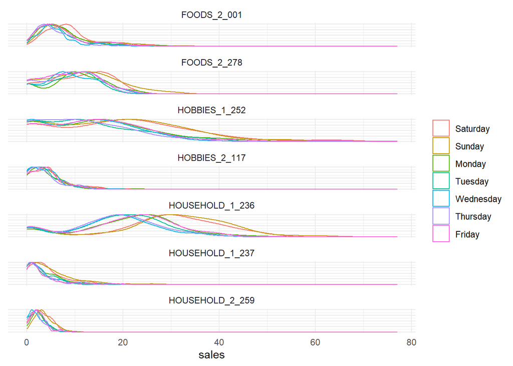

```r
set.seed(271)                                    # set seed for reproducibility
selected_items <- sample(data$item_id, 7)        # get 5 "random" items
data %>%
    filter(
        item_id %in% selected_items
    ) %>%
    group_by(
        date, item_id, weekday
    ) %>%
    summarise(
        sales = sum(sales)
    ) %>%
    ggplot(aes(sales, ..scaled.., color = weekday)) +
        geom_density() +
        facet_wrap(~ item_id, ncol = 1) +
        theme_minimal() +
        theme(
            axis.text.y = element_blank(),
            axis.ticks.y = element_blank(),
            axis.title.y = element_blank(),
            legend.title = element_blank()
        )
```

#### Item by Store

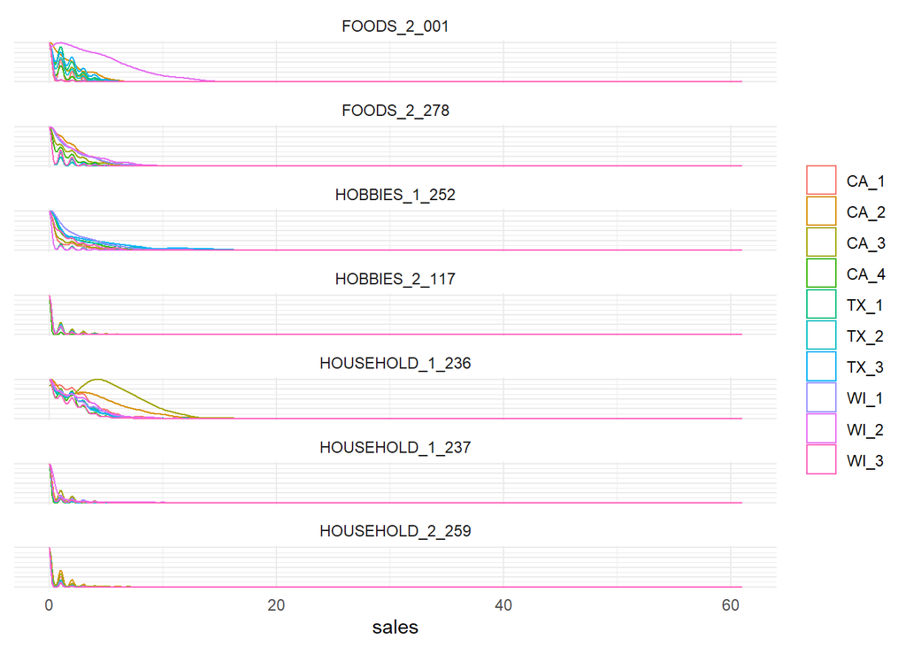

```r
data %>%
    filter(
        item_id %in% selected_items
    ) %>%
    group_by(
        date, item_id, store_id
    ) %>%
    summarise(
        sales = sum(sales)
    ) %>%
    ggplot(aes(sales, ..scaled.., color = store_id)) +
        geom_density() +
        facet_wrap(~ item_id, ncol = 1) +
        theme_minimal() +
        theme(
            axis.text.y = element_blank(),
            axis.ticks.y = element_blank(),
            axis.title.y = element_blank(),
            legend.title = element_blank()
        )
```